# DAPT 622 Assignment 1

Daniel Erb

January 14, 2019

```r
library(kableExtra)
library(corrplot)
library(stats)
library(factoextra)

candy_data <- read.table("G:/My Drive/vcu/Spring 2019/Statistics/Assignments/Assignment 1/DAPT_622_Assignment_1/Assignment_Materials/CandyBars.txt",sep=',',header=TRUE)

cd_sub <- candy_data[,c("Oz.pkg","Calories","Total.fat.g"
                  ,"Saturated.fat.g","Cholesterol.g"
                  ,"Sodium.mg","Carbohydrate.g"
                  ,"Dietary.fiber.g","Sugars.g"
                  ,"Protein.g","Vitamin.A..RDI"
                  ,"Vitamin.C..RDI","Calcium..RDI"
                  ,"Iron..RDI")]
```

# Part 1 - Exploratory Data Analysis

Perform the following exploratory data analysis tasks:

## Question 1

1. Consider all of the numeric variables (i.e. all of the variables except Brand and Name): Determine the variance/covariance matrix and the correlation matrix of these variables. Interpret briefly what you see.

```r
#Get variance-covariance matrix
covmat <- cov(cd_sub)
kable(covmat,caption = "Variance/Covariance Matrix for Candy Data", digits = 3) %>%
  kable_styling(bootstrap_options = c("striped", "hover", "condensed", "responsive"),
                full_width = TRUE, font_size = 10)
```

Variance/Covariance Matrix for Candy Data

|  | Oz.pkg | Calories | Total.fat.g | Saturated.fat.g | Cholesterol.g | Sodium.mg | Carbohydrate.g | Dietary.fiber.g | Sugars.g | Protein.g | Vitamin.A..RDI | Vitamin.C..RDI | Calcium..RDI | Iron..RDI |
| --- | --- | --- | --- | --- | --- | --- | --- | --- | --- | --- | --- | --- | --- | --- |
| Oz.pkg | 1.312 | 6.853 | 0.993 | 0.803 | 1.039 | -6.881 | -1.045 | 0.109 | 0.059 | 0.113 | -0.199 | -0.856 | 0.998 | -0.412 |
| Calories | 6.853 | 3699.939 | 277.532 | 134.768 | 47.063 | 375.383 | 213.615 | 25.770 | 179.781 | 66.889 | -29.720 | -98.382 | 31.988 | 10.868 |
| Total.fat.g | 0.993 | 277.532 | 31.622 | 15.082 | 12.129 | 8.102 | -9.549 | 2.465 | 1.880 | 7.163 | -1.339 | -8.148 | 6.232 | 1.485 |
| Saturated.fat.g | 0.803 | 134.768 | 15.082 | 11.611 | 8.374 | -28.500 | -2.022 | 1.004 | 4.225 | 1.139 | -1.169 | -4.924 | 3.536 | -0.181 |
| Cholesterol.g | 1.039 | 47.063 | 12.129 | 8.374 | 29.244 | -10.288 | -14.526 | -0.537 | 2.725 | -0.377 | 1.153 | -4.758 | 5.532 | -2.508 |
| Sodium.mg | -6.881 | 375.383 | 8.102 | -28.500 | -10.288 | 2299.957 | 59.658 | -6.938 | -2.958 | 26.290 | 16.633 | -16.259 | -33.965 | -24.244 |
| Carbohydrate.g | -1.045 | 213.615 | -9.549 | -2.022 | -14.526 | 59.658 | 77.399 | -0.250 | 43.757 | -3.896 | -4.842 | -8.789 | -9.742 | -3.097 |
| Dietary.fiber.g | 0.109 | 25.770 | 2.465 | 1.004 | -0.537 | -6.938 | -0.250 | 0.803 | -0.259 | 0.860 | -0.320 | 0.523 | 0.253 | 0.920 |
| Sugars.g | 0.059 | 179.781 | 1.880 | 4.225 | 2.725 | -2.958 | 43.757 | -0.259 | 48.956 | -3.370 | -3.311 | -10.462 | -2.906 | -4.698 |
| Protein.g | 0.113 | 66.889 | 7.163 | 1.139 | -0.377 | 26.290 | -3.896 | 0.860 | -3.370 | 4.165 | 0.569 | 2.207 | 3.068 | 2.236 |
| Vitamin.A..RDI | -0.199 | -29.720 | -1.339 | -1.169 | 1.153 | 16.633 | -4.842 | -0.320 | -3.311 | 0.569 | 4.722 | 6.138 | 3.211 | 3.535 |
| Vitamin.C..RDI | -0.856 | -98.382 | -8.148 | -4.924 | -4.758 | -16.259 | -8.789 | 0.523 | -10.462 | 2.207 | 6.138 | 37.457 | 12.677 | 10.751 |
| Calcium..RDI | 0.998 | 31.988 | 6.232 | 3.536 | 5.532 | -33.965 | -9.742 | 0.253 | -2.906 | 3.068 | 3.211 | 12.677 | 15.012 | 4.868 |
| Iron..RDI | -0.412 | 10.868 | 1.485 | -0.181 | -2.508 | -24.244 | -3.097 | 0.920 | -4.698 | 2.236 | 3.535 | 10.751 | 4.868 | 9.310 |

```r
#Get correlation matrix
corrmat <- cor(cd_sub)
kable(corrmat,caption = "Correlation Matrix for Candy Data", digits = 3) %>%
  kable_styling(bootstrap_options = c("striped", "hover", "condensed", "responsive"),
                full_width = TRUE, font_size = 10)
```

Correlation Matrix for Candy Data

|  | Oz.pkg | Calories | Total.fat.g | Saturated.fat.g | Cholesterol.g | Sodium.mg | Carbohydrate.g | Dietary.fiber.g | Sugars.g | Protein.g | Vitamin.A..RDI | Vitamin.C..RDI | Calcium..RDI | Iron..RDI |
| --- | --- | --- | --- | --- | --- | --- | --- | --- | --- | --- | --- | --- | --- | --- |
| Oz.pkg | 1.000 | 0.098 | 0.154 | 0.206 | 0.168 | -0.125 | -0.104 | 0.106 | 0.007 | 0.048 | -0.080 | -0.122 | 0.225 | -0.118 |
| Calories | 0.098 | 1.000 | 0.811 | 0.650 | 0.143 | 0.129 | 0.399 | 0.473 | 0.422 | 0.539 | -0.225 | -0.264 | 0.136 | 0.059 |
| Total.fat.g | 0.154 | 0.811 | 1.000 | 0.787 | 0.399 | 0.030 | -0.193 | 0.489 | 0.048 | 0.624 | -0.110 | -0.237 | 0.286 | 0.087 |
| Saturated.fat.g | 0.206 | 0.650 | 0.787 | 1.000 | 0.454 | -0.174 | -0.067 | 0.329 | 0.177 | 0.164 | -0.158 | -0.236 | 0.268 | -0.017 |
| Cholesterol.g | 0.168 | 0.143 | 0.399 | 0.454 | 1.000 | -0.040 | -0.305 | -0.111 | 0.072 | -0.034 | 0.098 | -0.144 | 0.264 | -0.152 |
| Sodium.mg | -0.125 | 0.129 | 0.030 | -0.174 | -0.040 | 1.000 | 0.141 | -0.161 | -0.009 | 0.269 | 0.160 | -0.055 | -0.183 | -0.166 |
| Carbohydrate.g | -0.104 | 0.399 | -0.193 | -0.067 | -0.305 | 0.141 | 1.000 | -0.032 | 0.711 | -0.217 | -0.253 | -0.163 | -0.286 | -0.115 |
| Dietary.fiber.g | 0.106 | 0.473 | 0.489 | 0.329 | -0.111 | -0.161 | -0.032 | 1.000 | -0.041 | 0.470 | -0.164 | 0.095 | 0.073 | 0.336 |
| Sugars.g | 0.007 | 0.422 | 0.048 | 0.177 | 0.072 | -0.009 | 0.711 | -0.041 | 1.000 | -0.236 | -0.218 | -0.244 | -0.107 | -0.220 |
| Protein.g | 0.048 | 0.539 | 0.624 | 0.164 | -0.034 | 0.269 | -0.217 | 0.470 | -0.236 | 1.000 | 0.128 | 0.177 | 0.388 | 0.359 |
| Vitamin.A..RDI | -0.080 | -0.225 | -0.110 | -0.158 | 0.098 | 0.160 | -0.253 | -0.164 | -0.218 | 0.128 | 1.000 | 0.462 | 0.381 | 0.533 |
| Vitamin.C..RDI | -0.122 | -0.264 | -0.237 | -0.236 | -0.144 | -0.055 | -0.163 | 0.095 | -0.244 | 0.177 | 0.462 | 1.000 | 0.535 | 0.576 |
| Calcium..RDI | 0.225 | 0.136 | 0.286 | 0.268 | 0.264 | -0.183 | -0.286 | 0.073 | -0.107 | 0.388 | 0.381 | 0.535 | 1.000 | 0.412 |
| Iron..RDI | -0.118 | 0.059 | 0.087 | -0.017 | -0.152 | -0.166 | -0.115 | 0.336 | -0.220 | 0.359 | 0.533 | 0.576 | 0.412 | 1.000 |

The variance/covariance matrix and correlation matrix show several positive correlations of note. For example, higher calorie counts tends to be associated with higher levels of total fat, saturated fat, carbohydrates, dietary fiber, sugars, and protein. Total fat, saturated fat and cholesterol are each positively correlated with one another. Protein correlates positively with total fat as well as dietary fiber, but interestingly is not very correlated with saturated fat or cholesterol. Vitamin A, Vitamin C, Calcium, and Iron are all positively correlated to one another to some extent.

## Question 2

2. Construct a scatterplot matrix of the variables specified in #1. Comment on what you observe.

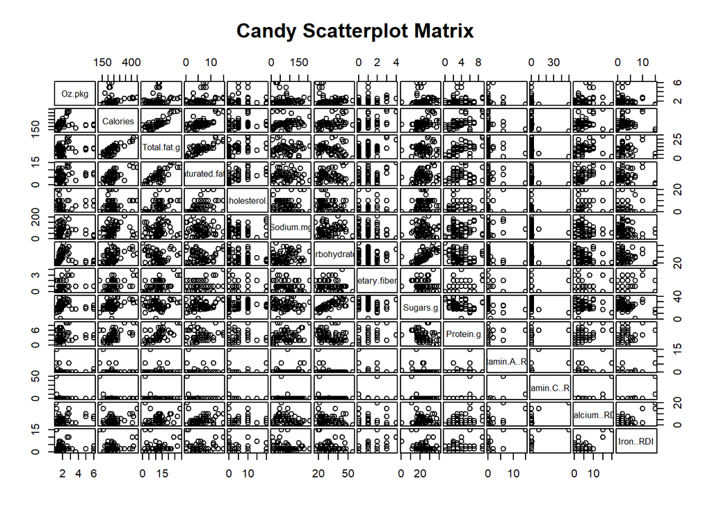

```r
pairs(~Oz.pkg
      +Calories
      +Total.fat.g
      +Saturated.fat.g
      +Cholesterol.g
      +Sodium.mg
      +Carbohydrate.g
      +Dietary.fiber.g
      +Sugars.g
      +Protein.g
      +Vitamin.A..RDI
      +Vitamin.C..RDI
      +Calcium..RDI
      +Iron..RDI
      ,data = cd_sub
      #,lower.panel=panel.smooth, upper.panel=panel.cor
      #,pch=20
      , gap = .2
      , main="Candy Scatterplot Matrix")
```

## Question 3

3. Construct a color map on correlations for the variables specified in #1. Comment on what you observe.

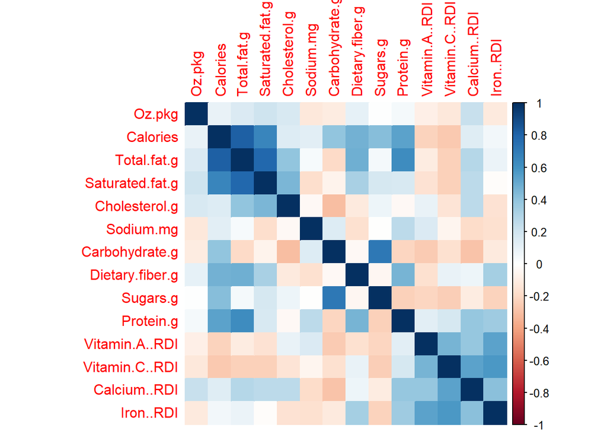

```r
corrmat <- cor(cd_sub)
corrplot(corrmat,method="color")
```

The color map of the correlations show very similar results as the variance/covariance and correlation matrices. They are quite a few strongly positive correlations. There are also far fewer strong negative correlations.

## Question 4

4. Use a probability plot to assess the multivariate normality of the variables specified in #1. Interpret.

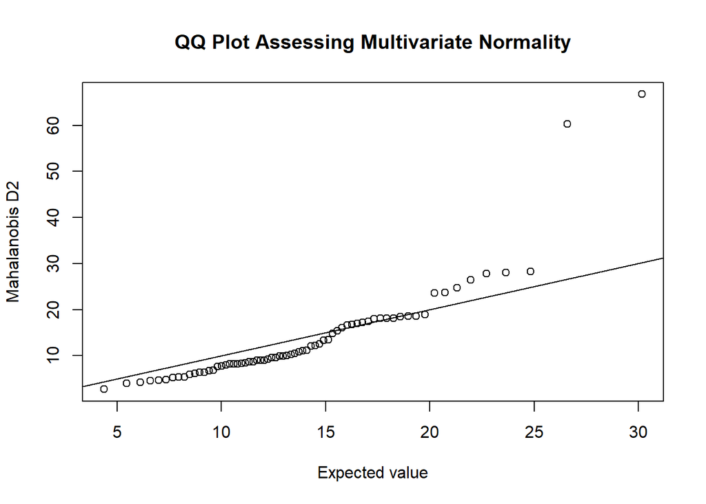

```r
x <- as.matrix(cd_sub)
center <- colMeans(x)
n <- nrow(x)
p <- ncol(x)
cov <- cov(x)
d <- mahalanobis(x,center,cov)
qqplot(qchisq(ppoints(n),df = p),d,
       main = "QQ Plot Assessing Multivariate Normality",
       ylab = "Mahalanobis D2",
       xlab = "Expected value")
abline(a = 0, b = 1)
```

# Part 2 - Principal Component Analysis

Reconsider the candy bar data. Perform a Principal Component Analysis on this data by carrying out the following steps:

## Section A

### Subsection i

Find and display the eigenvalues of the correlation matrix. Use these along with a Scree plot (and/or other means) to determine the number of principal components that are to be retained. How much of the variation in the data is explained by your chosen number of principal components? Remember that your goal is dimension reduction…so please be sensible in your choice of number of components

```r
#Compute the correlation matrix

 ##recall corrmat from above

#compute the eigenvalues and eigenvectors

ev <- eigen(corrmat)
ev$values
```

```
##  [1] 3.524396286 3.014941080 1.817274859 1.391856278 1.306887384
##  [6] 0.917613416 0.584278035 0.448070042 0.361235790 0.257673347
## [11] 0.169951041 0.152180103 0.050470606 0.003171733
```

```r
ev$vectors
```

```
##              [,1]        [,2]        [,3]        [,4]          [,5]
##  [1,] -0.13836701 -0.03028575 -0.28210056 -0.13346610 -0.1502984908
##  [2,] -0.44676158 -0.21129660  0.25105447 -0.02561249  0.1075082098
##  [3,] -0.50628502 -0.04952652 -0.07105755  0.14238906  0.0601991632
##  [4,] -0.42228100 -0.12782753 -0.20400742 -0.15719085 -0.0041070313
##  [5,] -0.19838325 -0.02063262 -0.48843647 -0.16764146  0.3476766869
##  [6,]  0.02267316 -0.04523813  0.20774941  0.44071607  0.6173441339
##  [7,]  0.05442706 -0.34047421  0.47227465 -0.31489874  0.1065372327
##  [8,] -0.32390529  0.05044892  0.24432391  0.11988085 -0.4555977039
##  [9,] -0.05405834 -0.36235485  0.22499606 -0.48302452  0.1937520777
## [10,] -0.35277577  0.20559982  0.23131328  0.35369522  0.0828631716
## [11,]  0.03704761  0.39868155  0.03883822 -0.14883177  0.4123934646
## [12,]  0.04661325  0.44421679  0.20327465 -0.24575273  0.0005621932
## [13,] -0.23221061  0.34525075 -0.09203717 -0.35208722  0.1290247406
## [14,] -0.11843070  0.40701087  0.30137405 -0.18909400 -0.1008810744
```

[output cut: 30 more lines]

```r
# scale = TRUE allows for correlation matrix to be utilized
# FALSE would allow for covariance matrix to be utilized
pca <- prcomp(cd_sub, scale = TRUE)
summary(pca)
```

```
## Importance of components:
##                           PC1    PC2    PC3     PC4     PC5     PC6
## Standard deviation     1.8773 1.7364 1.3481 1.17977 1.14319 0.95792
## Proportion of Variance 0.2517 0.2154 0.1298 0.09942 0.09335 0.06554
## Cumulative Proportion  0.2517 0.4671 0.5969 0.69632 0.78967 0.85521
##                            PC7     PC8    PC9    PC10    PC11    PC12
## Standard deviation     0.76438 0.66938 0.6010 0.50762 0.41225 0.39010
## Proportion of Variance 0.04173 0.03201 0.0258 0.01841 0.01214 0.01087
## Cumulative Proportion  0.89695 0.92895 0.9547 0.97316 0.98530 0.99617
##                           PC13    PC14
## Standard deviation     0.22466 0.05632
## Proportion of Variance 0.00361 0.00023
## Cumulative Proportion  0.99977 1.00000
```

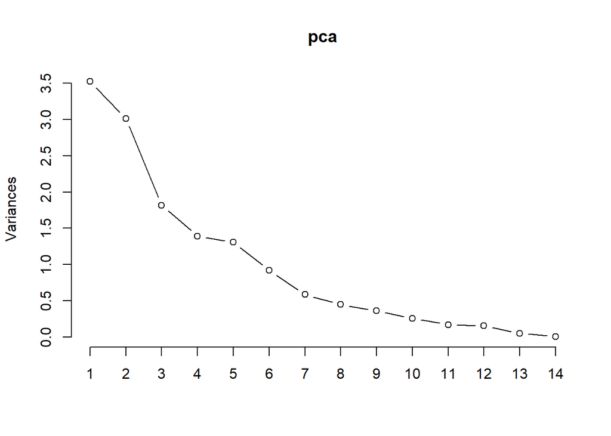

```r
#(show plots)

screeplot(pca, npcs = 14, type = "lines")
```

Considering the generated Scree plot as well as the biplot for the eigenvectors of the 14 principal components, 3 principal components should be kept. The first 3 principal components explain nearly 60% (0.5969) of the variability in the data, while keeping the number features relatively low.

### Subsection ii

Provide the loadings matrix. What do you learn from this matrix? Using this matrix, and as best as possible, interpret the first two principal components (I will expect some interpretation).

```r
#Loadings
loadings <- pca$rotation
loadings
```

```
##                         PC1         PC2         PC3         PC4
## Oz.pkg           0.13836701  0.03028575 -0.28210056  0.13346610
## Calories         0.44676158  0.21129660  0.25105447  0.02561249
## Total.fat.g      0.50628502  0.04952652 -0.07105755 -0.14238906
## Saturated.fat.g  0.42228100  0.12782753 -0.20400742  0.15719085
## Cholesterol.g    0.19838325  0.02063262 -0.48843647  0.16764146
## Sodium.mg       -0.02267316  0.04523813  0.20774941 -0.44071607
## Carbohydrate.g  -0.05442706  0.34047421  0.47227465  0.31489874
## Dietary.fiber.g  0.32390529 -0.05044892  0.24432391 -0.11988085
## Sugars.g         0.05405834  0.36235485  0.22499606  0.48302452
## Protein.g        0.35277577 -0.20559982  0.23131328 -0.35369522
## Vitamin.A..RDI  -0.03704761 -0.39868155  0.03883822  0.14883177
## Vitamin.C..RDI  -0.04661325 -0.44421679  0.20327465  0.24575273
## Calcium..RDI     0.23221061 -0.34525075 -0.09203717  0.35208722
## Iron..RDI        0.11843070 -0.40701087  0.30137405  0.18909400
##                           PC5          PC6          PC7         PC8
## Oz.pkg          -0.1502984908  0.855047727 -0.296819603  0.04107040
## Calories         0.1075082098  0.006526523  0.006958828 -0.13773225
## Total.fat.g      0.0601991632 -0.125867368 -0.006634126 -0.12347612
## Saturated.fat.g -0.0041070313 -0.212559935 -0.067104072 -0.07689674
## Cholesterol.g    0.3476766869 -0.206567051 -0.039903811  0.47760601
## Sodium.mg        0.6173441339  0.227602000 -0.021274065  0.30292567
## Carbohydrate.g   0.1065372327  0.114253044 -0.021155040 -0.01383890
## Dietary.fiber.g -0.4555977039 -0.021729562 -0.205283613  0.58192201
## Sugars.g         0.1937520777  0.025164590  0.011835698  0.12797225
## Protein.g        0.0828631716  0.176778330  0.215287693 -0.17124580
## Vitamin.A..RDI   0.4123934646 -0.041614609 -0.556427211 -0.13453703
## Vitamin.C..RDI   0.0005621932  0.049175179  0.369061304  0.43207499
## Calcium..RDI     0.1290247406  0.201313531  0.467546023 -0.19223678
## Iron..RDI       -0.1008810744 -0.152535158 -0.389568077 -0.10973321
##                           PC9         PC10        PC11         PC12
## Oz.pkg           0.0429785137 -0.111266260  0.09179527 -0.125835142
## Calories         0.0029781808 -0.133667257 -0.19455925 -0.197320303
## Total.fat.g      0.0043995066  0.064727628  0.15047303 -0.172639012
## Saturated.fat.g  0.6453325428  0.044572002  0.09807625 -0.009491387
## Cholesterol.g   -0.3673119402 -0.359344091 -0.16406546 -0.015018390
## Sodium.mg        0.3075848246 -0.054946918  0.19423091  0.311616380
## Carbohydrate.g   0.0820792622 -0.324559253 -0.47810473 -0.008365665
## Dietary.fiber.g -0.0482961217  0.302516954 -0.23259636  0.285450175
## Sugars.g        -0.2989489253  0.402599757  0.51805863  0.013665991
## Protein.g       -0.4127261445  0.002739177  0.01316793 -0.222015008
## Vitamin.A..RDI   0.0001652136  0.431651940 -0.31126466 -0.181864400
## Vitamin.C..RDI   0.2803139335 -0.044652749  0.10552984 -0.522756634
## Calcium..RDI     0.0040821049  0.130492898 -0.18943961  0.563838385
## Iron..RDI       -0.0690550681 -0.516850336  0.40207360  0.250426610
##                         PC13          PC14
## Oz.pkg          -0.018993869  0.0144761585
## Calories        -0.292644373 -0.6936491501
## Total.fat.g     -0.548671725  0.5687229945
## Saturated.fat.g  0.505096767  0.0111215854
## Cholesterol.g    0.095404207 -0.0021153710
## Sodium.mg       -0.046979813 -0.0158387726
## Carbohydrate.g   0.103163121  0.4271943242
## Dietary.fiber.g  0.011761124  0.0094039365
## Sugars.g         0.083264984 -0.0137498008
## Protein.g        0.556154109  0.1084398611
## Vitamin.A..RDI   0.011171987  0.0100502511
## Vitamin.C..RDI  -0.092069821  0.0035257612
## Calcium..RDI    -0.104253450  0.0004310668
## Iron..RDI       -0.005846437 -0.0130809886
```

Principal component 1 shows several major contributors. Calories, total fat, saturated fat, dietary fiber, and protein are the major positive contributors to this component while there are no seemingly significant negative contributors. This seems to suggests, as we might suspect from previous candy intake, that a candy bars content of calories, total fat, saturated fat, dietary fiber, and protein are positively related in some way.

Principal component 2 shows only a few slightly positive values for carbohydrates and sugars. This is in conjunction with some stronger negative loadings for vitamin A, vitamin C, calcium, and iron. This would suggest that a candy bars carbohydrate and sugar contents are opposed to increased values of vitamin A, vitamin C, calcium and iron. This might also make sense from our previous experience, as most people probably associate higher carbohydrate and sugar levels with lower vitamin and mineral content.

### Subsection iii

Construct a biplot of the loadings and scores for the first two principal components. For this plot, color the observations based on Brand. Are there any natural groupings of the observations? Are there any unusual observations?

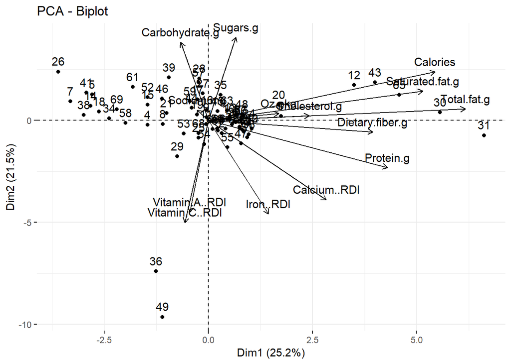

```r
#Biplot with vectors labelled
fviz_pca_biplot(pca, col.var = "black")
```

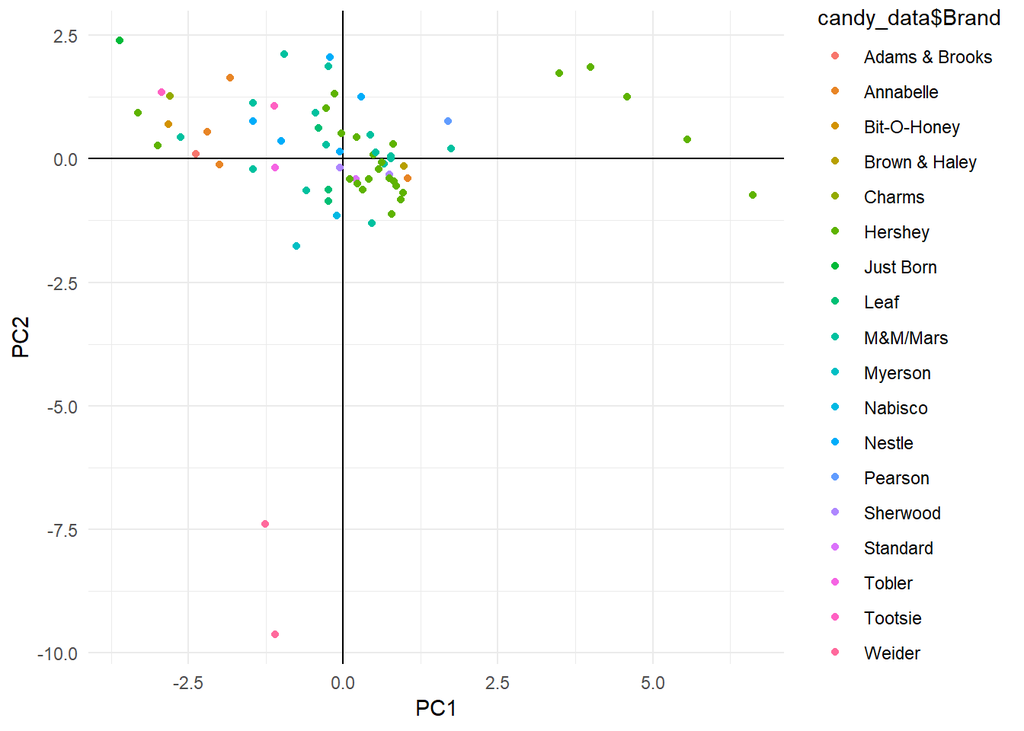

```r
#candyBar_scores <- as.data.frame(pca$x)
ggplot(data=as.data.frame(pca$x), aes(x=PC1, y=PC2,color = candy_data$Brand)) +
  geom_hline(yintercept=0) +
  geom_vline(xintercept=0) +
  geom_point() +
  theme_minimal()
```

## Section B

### Subsection i

Find and display the eigenvalues of the correlation matrix. Use these along with a Scree plot (and/or other means) to determine the number of principal components that are to be retained. How much of the variation in the data is explained by your chosen number of principal components? Remember that your goal is dimension reduction…so please be sensible in your choice of number of components

```r
#Compute the correlation matrix

 ##recall corrmat from above

#compute the eigenvalues and eigenvectors

ev <- eigen(covmat)
ev$values
```

```
##  [1] 3843.7796063 2211.5895837  105.9160657   47.7953019   31.9762990
##  [6]   10.6636412    5.9908586    5.7514763    4.2398866    1.6855083
## [11]    1.1284265    0.4709526    0.3285052    0.1937451
```

```r
ev$vectors
```

```
##               [,1]         [,2]        [,3]         [,4]         [,5]
##  [1,]  0.001317846 -0.003785997  0.01470432 -0.022437688 -0.017012267
##  [2,]  0.964850830 -0.234262193  0.03697614  0.033579418  0.036278525
##  [3,]  0.070894560 -0.026567546  0.29458286 -0.126254718 -0.042703435
##  [4,]  0.032542713 -0.027234287  0.10932278 -0.115547353 -0.124342875
##  [5,]  0.011407762 -0.009966577  0.20819718 -0.351150968 -0.671109637
##  [6,]  0.236825666  0.970801874  0.01739395 -0.001735413 -0.018654732
##  [7,]  0.058805295  0.003533440 -0.75454257  0.158465408  0.016202588
##  [8,]  0.006089684 -0.005820847  0.02001455  0.030691497  0.037388773
##  [9,]  0.046339175 -0.020807915 -0.47901326 -0.157522129 -0.550914212
## [10,]  0.018460947  0.004356509  0.10401825  0.103934949  0.063927861
## [11,] -0.006622754  0.010486737  0.05553683  0.125201039 -0.118350679
## [12,] -0.026398124  0.003477186  0.10517833  0.775311288 -0.320321724
## [13,]  0.005861327 -0.018542412  0.16394848  0.272377505 -0.323124498
## [14,]  0.001090951 -0.011812641  0.07073126  0.305165804 -0.009877136
```

[output cut: 30 more lines]

```r
# scale = TRUE allows for correlation matrix to be utilized
# FALSE would allow for covariance matrix to be utilized
pca <- prcomp(cd_sub, scale = FALSE)
summary(pca)
```

```
## Importance of components:
##                            PC1     PC2      PC3     PC4    PC5    PC6
## Standard deviation     61.9982 47.0275 10.29155 6.91341 5.6548 3.2655
## Proportion of Variance  0.6129  0.3526  0.01689 0.00762 0.0051 0.0017
## Cumulative Proportion   0.6129  0.9655  0.98242 0.99005 0.9951 0.9968
##                            PC7     PC8     PC9    PC10    PC11    PC12
## Standard deviation     2.44762 2.39822 2.05910 1.29827 1.06227 0.68626
## Proportion of Variance 0.00096 0.00092 0.00068 0.00027 0.00018 0.00008
## Cumulative Proportion  0.99780 0.99872 0.99939 0.99966 0.99984 0.99992
##                           PC13    PC14
## Standard deviation     0.57315 0.44016
## Proportion of Variance 0.00005 0.00003
## Cumulative Proportion  0.99997 1.00000
```

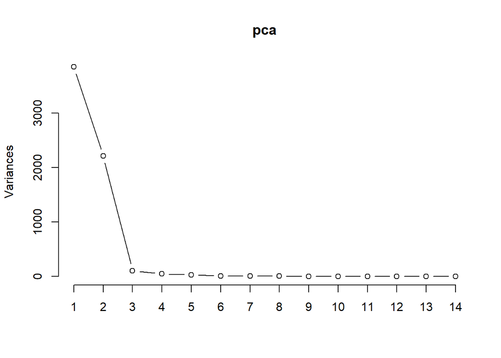

```r
#(show plots)

screeplot(pca, npcs = 14, type = "lines")
```

### Subsection ii

Provide the loadings matrix. What do you learn from this matrix? Using this matrix, and as best as possible, interpret the first two principal components (I will expect some interpretation).

```r
#Loadings
loadings <- pca$rotation
loadings
```

```
##                          PC1          PC2         PC3          PC4
## Oz.pkg           0.001317846 -0.003785997  0.01470432 -0.022437688
## Calories         0.964850830 -0.234262193  0.03697614  0.033579418
## Total.fat.g      0.070894560 -0.026567546  0.29458286 -0.126254718
## Saturated.fat.g  0.032542713 -0.027234287  0.10932278 -0.115547353
## Cholesterol.g    0.011407762 -0.009966577  0.20819718 -0.351150968
## Sodium.mg        0.236825666  0.970801874  0.01739395 -0.001735413
## Carbohydrate.g   0.058805295  0.003533440 -0.75454257  0.158465408
## Dietary.fiber.g  0.006089684 -0.005820847  0.02001455  0.030691497
## Sugars.g         0.046339175 -0.020807915 -0.47901326 -0.157522129
## Protein.g        0.018460947  0.004356509  0.10401825  0.103934949
## Vitamin.A..RDI  -0.006622754  0.010486737  0.05553683  0.125201039
## Vitamin.C..RDI  -0.026398124  0.003477186  0.10517833  0.775311288
## Calcium..RDI     0.005861327 -0.018542412  0.16394848  0.272377505
## Iron..RDI        0.001090951 -0.011812641  0.07073126  0.305165804
##                          PC5         PC6          PC7          PC8
## Oz.pkg           0.017012267 -0.00593699 -0.145215861  0.083240390
## Calories        -0.036278525  0.01397038  0.003056272 -0.007815010
## Total.fat.g      0.042703435 -0.17930053  0.065516831 -0.092572836
## Saturated.fat.g  0.124342875  0.02097668 -0.151189287 -0.177962436
## Cholesterol.g    0.671109637  0.55757925  0.147756531 -0.046008132
## Sodium.mg        0.018654732 -0.01168903 -0.004402054  0.002072956
## Carbohydrate.g  -0.016202588  0.47380015 -0.087792724  0.082086448
## Dietary.fiber.g -0.037388773 -0.03023096  0.069796273 -0.081788386
## Sugars.g         0.550914212 -0.64426753  0.134933009 -0.031780310
## Protein.g       -0.063927861 -0.09750603  0.014883592  0.109321651
## Vitamin.A..RDI   0.118350679  0.01114931  0.325658463  0.395804999
## Vitamin.C..RDI   0.320321724  0.02325978 -0.003651935 -0.517114625
## Calcium..RDI     0.323124498 -0.06846913 -0.608094352  0.597446684
## Iron..RDI        0.009877136  0.02842030  0.650421367  0.378481373
##                          PC9        PC10         PC11         PC12
## Oz.pkg           0.003553378 -0.05567830  0.952748741 -0.155611808
## Calories         0.038123226  0.02407380  0.012283240  0.010649922
## Total.fat.g     -0.118459434 -0.02018776 -0.155473290 -0.499672060
## Saturated.fat.g -0.853853803 -0.07169132  0.030848624  0.397712306
## Cholesterol.g    0.200990872 -0.06373535  0.012502548  0.056007213
## Sodium.mg       -0.017318609 -0.01741825  0.001478504 -0.003345824
## Carbohydrate.g  -0.115545512 -0.02563223 -0.053796360 -0.068789806
## Dietary.fiber.g  0.018642874 -0.12625647  0.181812414  0.171296185
## Sugars.g         0.032699205 -0.04699015  0.015776034  0.039295436
## Protein.g        0.356030130 -0.04677780  0.015715660  0.719356993
## Vitamin.A..RDI  -0.180642642  0.80730179  0.079278708  0.046244718
## Vitamin.C..RDI   0.039494045  0.09219957  0.045181048 -0.046942240
## Calcium..RDI    -0.024066060 -0.14657146 -0.146231365 -0.071028210
## Iron..RDI       -0.196066419 -0.53262888  0.026098988 -0.046862631
##                         PC13         PC14
## Oz.pkg           0.151354402 -0.113828538
## Calories         0.006836146  0.088111353
## Total.fat.g     -0.046291865 -0.744504624
## Saturated.fat.g  0.072520562 -0.062247034
## Cholesterol.g   -0.011014508 -0.003463192
## Sodium.mg       -0.003599273  0.003713616
## Carbohydrate.g  -0.032966857 -0.374390365
## Dietary.fiber.g -0.949387148 -0.068494135
## Sugars.g         0.012954507  0.010517689
## Protein.g        0.186500873 -0.520385765
## Vitamin.A..RDI  -0.093718180 -0.051629281
## Vitamin.C..RDI   0.047101373 -0.005394009
## Calcium..RDI    -0.117581751  0.020445434
## Iron..RDI        0.085489177  0.046984976
```

### Subsection iii

Construct a biplot of the loadings and scores for the first two principal components. For this plot, color the observations based on Brand. Are there any natural groupings of the observations? Are there any unusual observations?

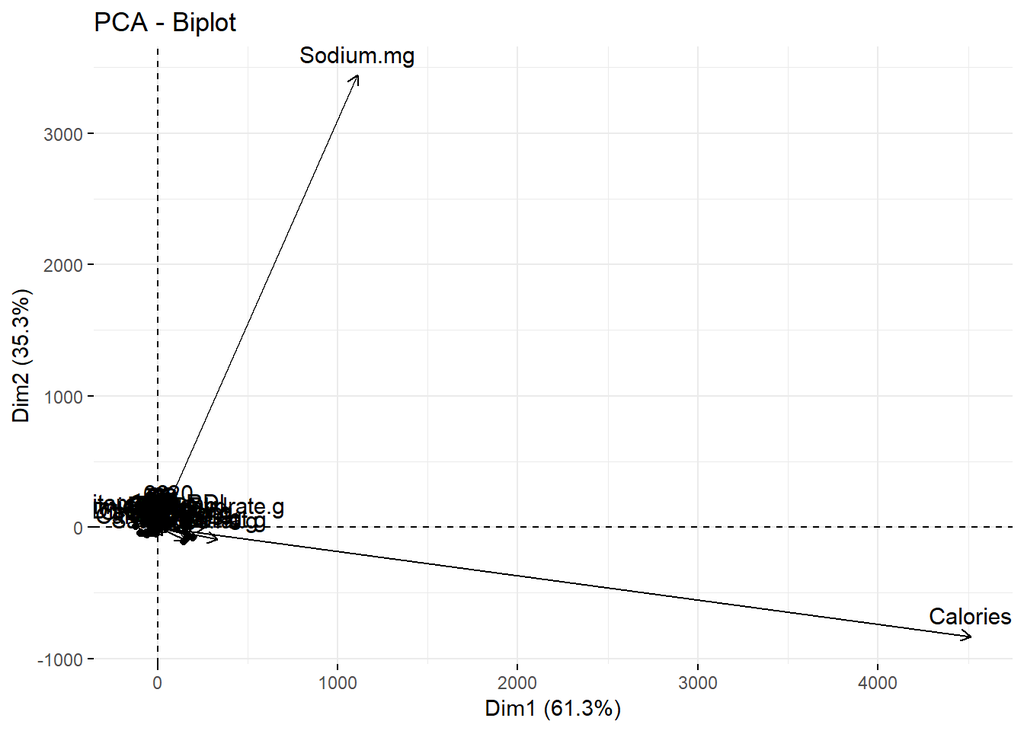

```r
#Biplot with vectors labelled
fviz_pca_biplot(pca, col.var = "black")
```

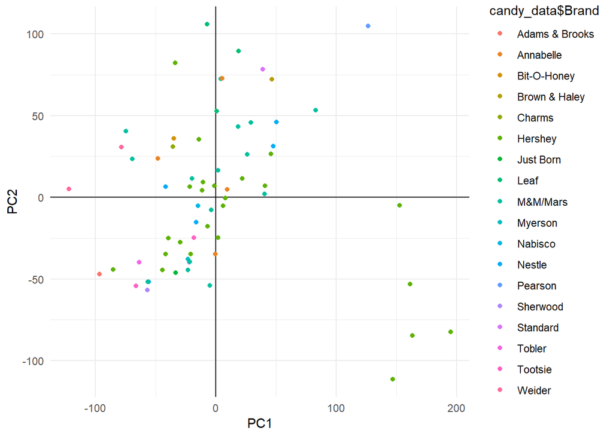

```r
#candyBar_scores <- as.data.frame(pca$x)
ggplot(data=as.data.frame(pca$x), aes(x=PC1, y=PC2,color = candy_data$Brand)) +
  geom_hline(yintercept=0) +
  geom_vline(xintercept=0) +
  geom_point() +
  theme_minimal()
```

When using the covariance matrix, an analyst might overestimate the power of calories and sodium to explain most of the variation in the data. This is shown especially in the biplot and loadings for principal components 1 and 2. This effect is partially skewed since the units for the dimensions are not consistent. Since calories and sodium utilize a unit that puts their measurements about an order or two of magnitude higher, their importance is most likely over stated, as variances and covariances involving these measurements will naturally be higher. An analyst might try transforming some of the columns of data so that the magnitudes are more in line with one another and would hopefully allow for a more accurate principal component analysis.

# End

*Thanks!*